# Final

Tümay Kır

9/14/2020

## 1.Part I

### 1.1. COVID Analysis

Within the pandemic period, many countries followed different solution ways such as herd immunity, vaccine or quarantine. All these strategies brought out both positive and negative outcomes. However nowadays, people get acquainted with this virus, so governments usually don’t want to alarm the people anymore. This action obviously lead to inaccurate COVID-19 data among people. Since Turkey underreports the COVID test results and statistical data, the pandemic loses its importance naturally. Thus,the precautions that are not taken by communities causes really crucial consequences and the increase in the possibility of recurrence of COVID-19.

### 1.2. EDA Workflow

My EDA workflow is as follows: - Clean the data: I make some modifications in dataset in order to manipulate it easily. i.e. arranging time or changing the column names. - Make some calculations: I calculate some numbers which might be helpful later on. - Plot some graphs: I create basic plots to understand the data better. - Main Analysis: The main theme in my mind is implemented in this part of my workflow. - Comments and References: After I explain all of my analysis, I add a references part. Then, my explatory data analysis is done. If I had the sample dataset in the question, I would use my workflow again and present the argument that I am inclined to. Since EDA process is a subjective process (in my opinion), I examine the data in my way. To distribute the fund in a fair way, I also search the need for these subjects in the country and determine where there is a deficiency. To sum up, I perform my personal analysis without ignoring some facts and the things what data say.

### 1.3. `starwars` Dataset

In this analysis, the column “films” in `starwars` dataset is generally not used for manipulation due to its vector values. So, I tried to benefit from this column. I used the function, unnest, so that the combined data is splitted and become available. I wonder how many movies the actors/actresses perform and count them. Thus, a new data frame `how_many_movies` is created.

```r
starwars<-starwars
starwars<-starwars %>% unnest(films)
how_many_movies<-starwars%>%group_by(name)%>%count()
```

The plot shows the number of films for each actor/actress and their names.

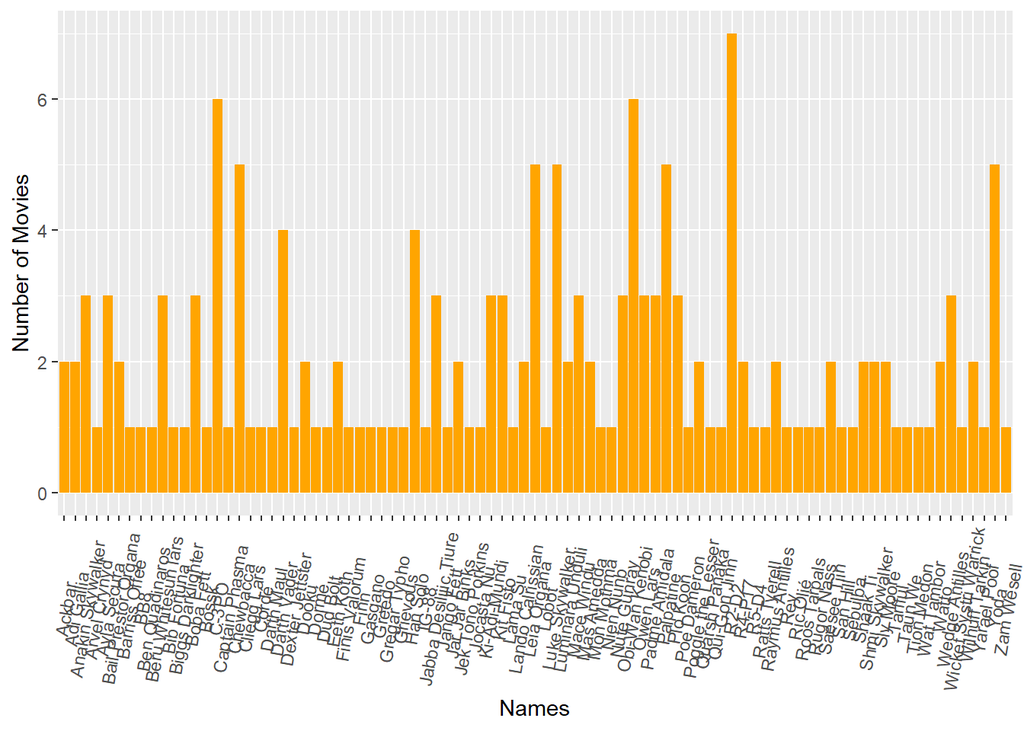

```r
how_many_movies%>%ggplot(aes(x=name,y=n))+
  geom_bar(stat="identity",position="dodge",fill="orange")+
  theme(axis.text.x = element_text(angle = 80, vjust = .5)) +
  ylab("Number of Movies")+
  xlab("Names")
```

## 2. Part II: Extended Analysis of the Group Project (Tourist Visits to Turkey)

In this part, I examine the country based **percentage** of visits to Turkey as an improvement.The percentages of visits for all the countries and continents are calculated with respect to the months and years. In this way, the contribution of foreign countries to Turkey’s tourism sector can be analyzed yearly and monthly.

First of all, I studied on the monthly percentages of touristic visits. By grouping `data_pivot` based on months and countries, the total numbers of tourists for each country are calculated. Then, I calculated the total number of **monthly** visits regardless of the countries. By joining these two datasets I get the required data so that the monthly touristic percentage can be calculated.

```r
countries_by_month<-data_pivot%>%group_by(Month,Country)%>%summarize(total_monthly=sum(value))
total_monthly<-data_pivot%>%group_by(Month)%>%summarize(total_monthly=sum(value))
data_monthly<-countries_by_month%>%left_join(total_monthly,by="Month")
data_monthly<-data_monthly[!grepl("Total|Africa|Other", data_monthly$Country),]
colnames(data_monthly)[3]  <- "Visits"
colnames(data_monthly)[4]  <- "Total by Month"
data_monthly<-data_monthly%>%mutate(Percentage=100*(Visits/`Total by Month`))
```

This plot indicates the monthly percentages of touristic visits to Turkey according to each country but continents or regions. (Continents and regions are removed from the data since they cause a confusion in the data analysis.)

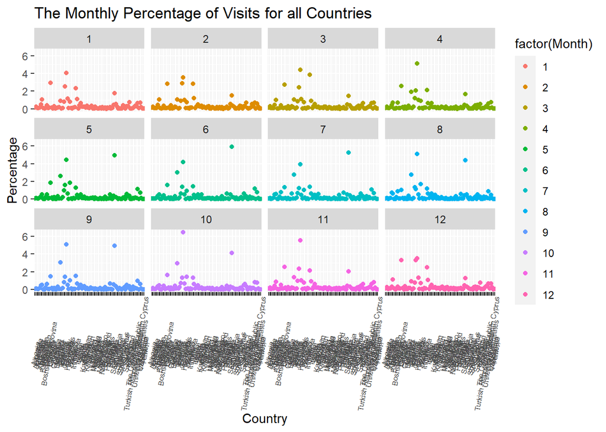

```r
data_monthly%>%ggplot(aes(x=Country,y=Percentage))+
  geom_point(aes(color=factor(Month)))+
  theme(axis.text.x = element_text(angle = 80, vjust = .5,size=6))+
  ggtitle("The Monthly Percentage of Visits for all Countries")+
  facet_wrap(~Month)
```

If the dataset `data_monthly` is examined closely, it can be observed that the countries which generate tourists with the highest monthly percentages are as follows:

```r
the_highest_percentages_monthly<-data_monthly%>%filter(Percentage==max(Percentage))
head(the_highest_percentages_monthly,12)
```

```
## # A tibble: 12 x 5
## # Groups:   Month [12]
##    Month Country  Visits `Total by Month` Percentage
##    <dbl> <chr>     <dbl>            <dbl>      <dbl>
##  1     1 Germany 2014619        49877457        4.04
##  2     2 Germany 1601816        45311755        3.54
##  3     3 Germany 2558725        57887414        4.42
##  4     4 Germany 3672090        71883130        5.11
##  5     5 Russia  5331269       108156130        4.93
##  6     6 Russia  7555575       127581819        5.92
##  7     7 Russia  7836023       149399130        5.25
##  8     8 Germany 9297051       182318508        5.10
##  9     9 Germany 7702351       151112899        5.10
## 10    10 Germany 8273957       128045168        6.46
## 11    11 Germany 3632209        65715276        5.53
## 12    12 Germany 1691282        48426369.       3.49
```

Above analysis says that Germany has the highest percentage among the other countries, in all the months except May, June and July. In these months Russia gets ahead of Germany.

However, due to the excessive number of countries, it is hard to see the variables on the x-axis. Thus, I chose some of the most popular countries for better investigation.

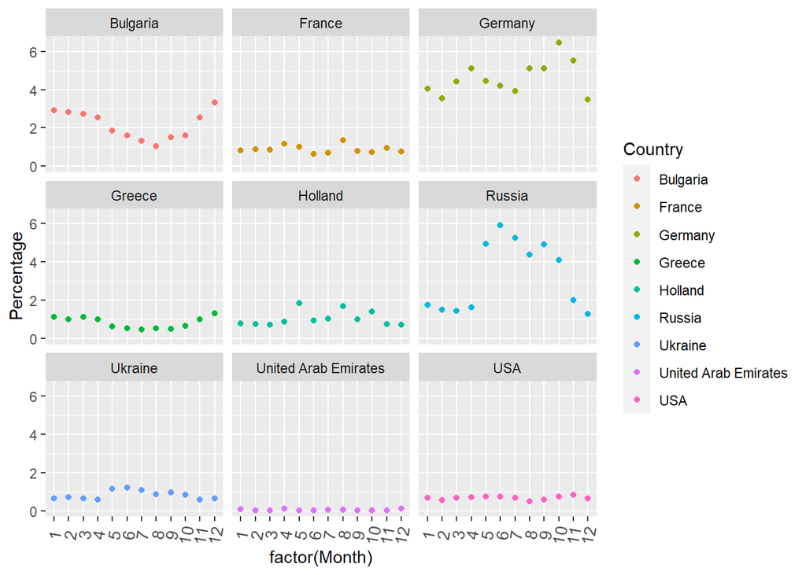

```r
data_monthly%>%filter(Country %in% c("Russia","Germany","USA","United Kingdom","Bulgaria","Holland","France","United Arab Emirates","Ukraine","Greece"))%>%
  ggplot(aes(x=factor(Month),y=Percentage))+
  geom_point(aes(color=Country))+
  theme(axis.text.x = element_text(angle = 80, vjust = .5,size=10))+
  facet_wrap(~Country)
```

After the monthly analysis, I grouped the dataset yearly and calculate the percentage for this case.

```r
countries_by_year<-data_pivot%>%group_by(Year,Country)%>%summarize(total_yearly=sum(value))
total_yearly<-data_pivot%>%group_by(Year)%>%summarize(total_yearly=sum(value))
data_yearly<-countries_by_year%>%left_join(total_yearly,by="Year")
data_yearly<-data_yearly[!grepl("Total|Africa|Other", data_yearly$Country),]
colnames(data_yearly)[3]  <- "Visits"
colnames(data_yearly)[4]  <- "Total by Year"
data_yearly<-data_yearly%>%mutate(Percentage=100*(Visits/`Total by Year`))
```

This graph shows the yearly percentage analysis of touristic visits to Turkey for all countries.

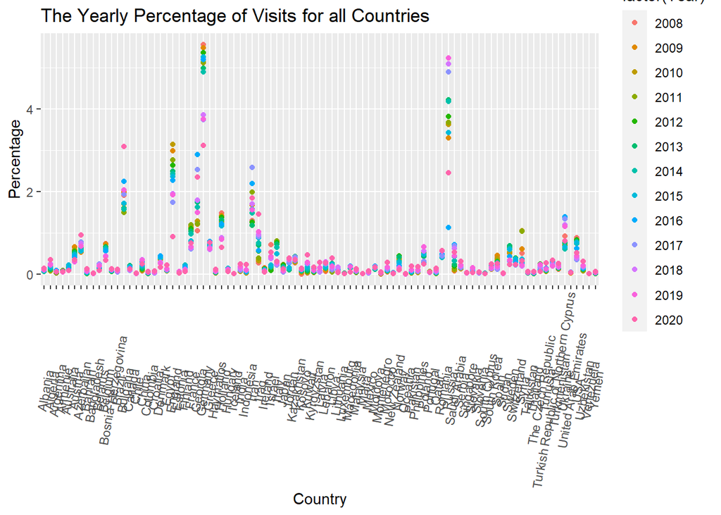

```r
data_yearly%>% ggplot(aes(x=Country,y=Percentage,color=factor(Year)))+
  geom_point()+
  theme(axis.text.x = element_text(angle = 80, vjust = .5))+
  ggtitle("The Yearly Percentage of Visits for all Countries")
```

Nevertheless, in yearly analysis, the dynamics has changed.In 2017, 2018 and 2019, Russia comes first in the ranking. The highest percentage of yearly touristic actions are generally taken by Germany comparing to other countries.

```r
the_highest_percentages_yearly<-data_yearly%>%filter(Percentage==max(Percentage))
head(the_highest_percentages_yearly,13)
```

```
## # A tibble: 13 x 5
## # Groups:   Year [13]
##     Year Country  Visits `Total by Year` Percentage
##    <dbl> <chr>     <dbl>           <dbl>      <dbl>
##  1  2008 Germany 4396948       79119301        5.56
##  2  2009 Germany 4481571       81859537        5.47
##  3  2010 Germany 4370248       85349506        5.12
##  4  2011 Germany 4815156       93767343        5.14
##  5  2012 Germany 5025660       93799190        5.36
##  6  2013 Germany 5048199      101225752.       4.99
##  7  2014 Germany 5251870      107267000        4.90
##  8  2015 Germany 5593065      106455084        5.25
##  9  2016 Germany 3928954       75639635        5.19
## 10  2017 Russia  4699557       96090918        4.89
## 11  2018 Russia  5937850      116668019        5.09
## 12  2019 Russia  7000407      133904016        5.23
## 13  2020 Germany  454531       14569754        3.12
```

Again, I filtered some specific countries in order to observe the percentages more clearly. The graph illustrates the percentage contribution of touristic events by these countries.

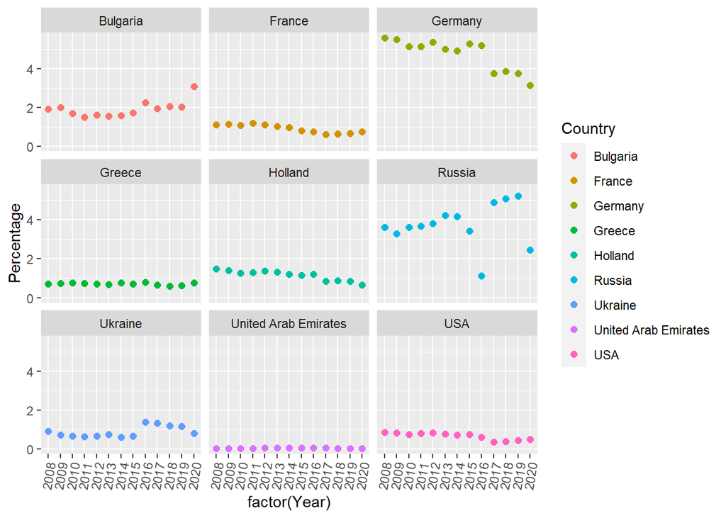

```r
data_yearly%>%filter(Country %in% c("Russia","Germany","USA","United Kingdom","Bulgaria","Holland","France","United Arab Emirates","Ukraine","Greece"))%>%
  ggplot(aes(x=factor(Year),y=Percentage,color=Country))+
  geom_point(size=2)+
  theme(axis.text.x = element_text(angle = 80, vjust = .5))+
  facet_wrap(~Country)
```

## 3. Part III: Real Life Data Analysis: Car Sales

### 3.1. Data File

```r
car_data<-within(car_data, Date <- sprintf("%d-%02d", year, month))
car_data$Date <- parse_date_time(car_data$Date, "ym")
save(car_data, file = "cardata.RData")
```

My Data Link

### 3.2. Explotory Data Analysis

Car Sales data is arranged. Time column is moved to first column.

```r
car_data<-car_data[,c(ncol(car_data),1:(ncol(car_data)-1))]
```

To have an insight about the data, some sales analysis are conducted. These code and the plot show that the brand with maximum total sales, year by year.

```r
data_total_year<-car_data%>%group_by(brand_name,year)%>%summarise(total=sum(total_total))
```

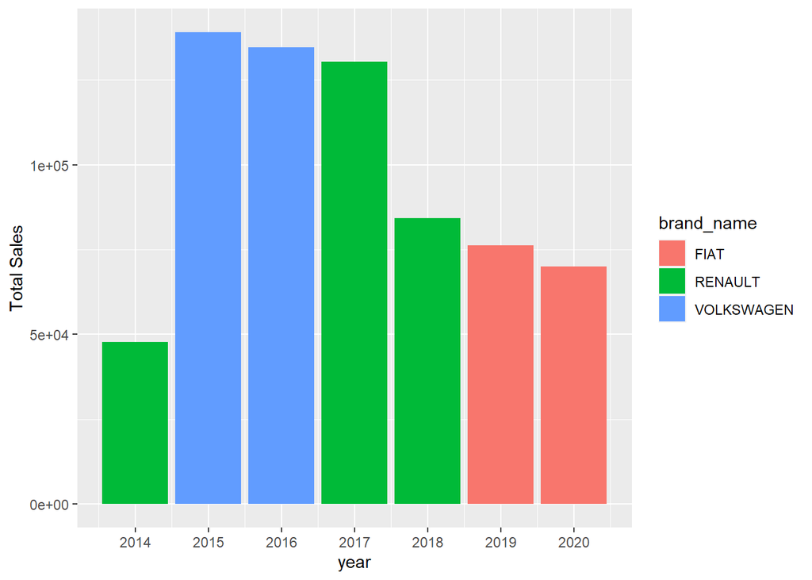

```r
data_total_year<-data_total_year%>%group_by(year)%>%filter(total==max(total))

data_total_year%>%ggplot(aes(x=year,y=total,fill=brand_name))+
  geom_bar(stat="identity",position = "dodge")+
  scale_x_continuous(breaks=2014:2020)+
  ylab("Total Sales")
```

After, I want to look the data closely. I conducted an analysis which indicates total monthly sales with respect to brands. To do that, the data is grouped by months and `brand_name`. Then, in order to see the bars of the brands with lower sales number, I split `data_monthly` into two group: **greater than 500 sales** and **the lowers**.

```r
data_monthly<-car_data%>%group_by(brand_name,month)%>%summarise(mean_total=mean(total_total))
data_monthly_small<-data_monthly%>%filter(mean_total<=500)
data_monthly_big<-data_monthly%>%filter(mean_total>500)
```

The graph for each dataset are plotted by using faceting.

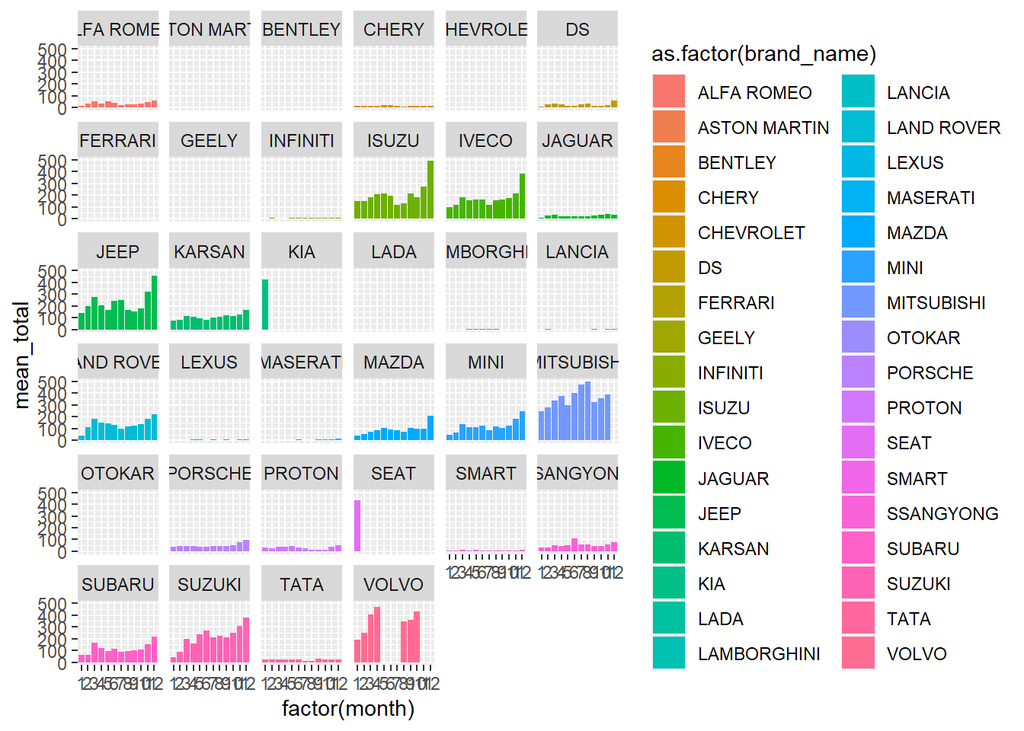

```r
data_monthly_small%>%ggplot(aes(x=factor(month),y=mean_total,fill=as.factor(brand_name)))+
  geom_bar(stat="identity",position = "dodge")+
  facet_wrap(~as.factor(brand_name))
```

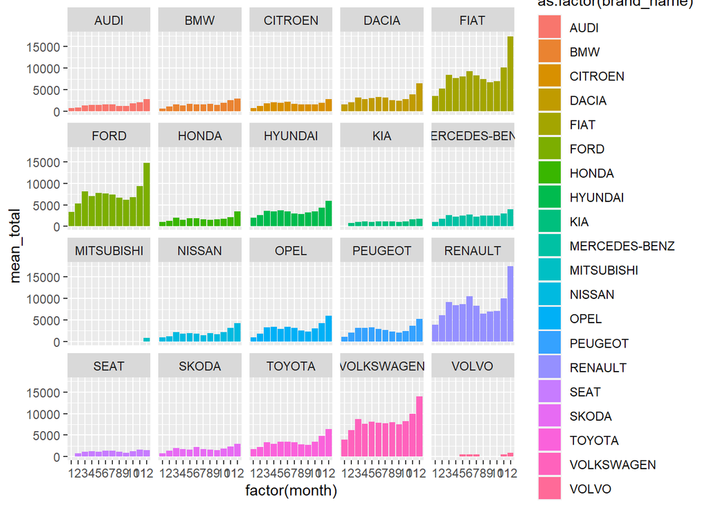

```r
data_monthly_big%>%ggplot(aes(x=factor(month),y=mean_total,fill=as.factor(brand_name)))+
  geom_bar(stat="identity",position = "dodge")+
  facet_wrap(~as.factor(brand_name))
```

My main theme about `car_data` is as follows:

I want to observe the foreign dependency in car sales by looking at the imported and domestic car sales ratio. When the ratio of domestic/imported is higher than “1”, internal trading is appreciated. After calculating the percentages, I find the difference between them. In this way, the change of the dependency in time (monthly) can be observed. When any difference value among the variables (diff1, diff2 and diff3) is negative, it means that external dependency is increasing in car sales. In contrast, if diff values are greater than “0”, then internal trade gains value.

diff1 represents the difference for automobile, diff2 represents the difference for commercial vehicle and diff3 indicates the difference for all type of car sales.

```r
car_data<-add_column(car_data, Percentage1 = car_data$auto_dom/car_data$auto_imp, .after = "auto_imp")
car_data<-add_column(car_data, Percentage2 = car_data$comm_dom/car_data$comm_imp, .after = "comm_imp")
car_data<-add_column(car_data, Percentage3 = car_data$total_dom/car_data$total_imp, .after = "total_imp")

data_ordered<-arrange(car_data,car_data$brand_name)
incremental_data<-data_ordered%>%group_by(brand_name)%>%summarise(diff1=diff(Percentage1),diff2=diff(Percentage2), diff3=diff(Percentage3))
incremental_data<-incremental_data %>% group_by(brand_name) %>% mutate(time = row_number())
incremental_data%>%filter(brand_name=="TOYOTA")
```

```
## # A tibble: 71 x 5
## # Groups:   brand_name [1]
##    brand_name  diff1 diff2   diff3  time
##    <chr>       <dbl> <dbl>   <dbl> <int>
##  1 TOYOTA     -0.110     0 -0.0517     1
##  2 TOYOTA     -0.358     0 -0.365      2
##  3 TOYOTA      0.235     0  0.326      3
##  4 TOYOTA      0.641     0  0.268      4
##  5 TOYOTA      0.865     0  1.13       5
##  6 TOYOTA     -0.728     0 -1.05       6
##  7 TOYOTA     -1.12      0 -0.740      7
##  8 TOYOTA      0.499     0  0.139      8
##  9 TOYOTA      2.69      0  2.29       9
## 10 TOYOTA     -2.33      0 -1.46      10
## # ... with 61 more rows
```

[figure not shown]

```r
Toyota<-incremental_data%>%filter(brand_name=="TOYOTA")

Toyota%>%ggplot( aes(x=time))+
  geom_line(size=1,aes(y = diff1,color="red"))+
  geom_line(size=1,aes(y = diff2,color="yellow"))+
  geom_line(size=1,aes(y =diff3,color="blue"))+
  geom_hline(aes(yintercept=0))+
  ylab("Differences")+
  scale_colour_manual(name = "Differences", labels=c("diff1","diff2","diff3"),
                     values=c( "red", "yellow","blue"))
```

## 4. References

-https://stackoverflow.com/ -https://github.com/pjournal/boun01g-data-mine-r-s/blob/gh-pages/Final%20TakeHome/all_data?raw=true